# Project Group 2: Project EDA

- Zev Burton - zb111
- Matthew Gnanadass - mag428
- Olivier Kuhn de Chizelle - oyk3
- Qihang Wang - qw123

### Business Questions

1. **To what extent do major sporting events affect posting and commenting on various subreddits?**
   - **Business Goal:** Determine whether engagement on subreddits is impacted by major sporting and e-sporting events.
   - **Technical Proposal:**
     - Gather a list of the top sports and esports competitions for a given subreddit, such as the Finals for the NBA or Worlds for League of Legends.
     - Compare engagement at those times with engagement during other parts of the year through comments and post counts.
     - Compare trends in both groups to see if there is a difference, or if the trend holds for both types of competition events.
     - Identify if subreddit activity decreases during the off-season.
2. **Is there a difference between traditional sports and esports?**
   - **Business Goal:** Identify differences in sports and esports e-communities.
   - **Technical Proposal:**
     - Identify the distributions of comments, posts, and likes for every subreddit.
     - Gather summary statistics for each subreddit using aggregation techniques for each of those attributes, including creating dummy variables for post and comment lengths by word.
     - Graph these summary statistics to directly compare between sports communities and esports communities.
3. **Is there a way to measure good vs bad engagement?**
   - **Business Goal:** Define and determine good engagement (what should be strived for in moderation) and bad engagement (what should be heavily moderated).
   - **Technical Proposal:**
     - Gather comments for each subreddit using the given data.
     - Run sentiment analysis and hate speech analysis using NLP on the comments to determine a positive for negative comment.
     - Use NLP analysis to determine a percentage of good and bad engagement using those parameters.
4. **How does moderation impact overall subreddit health?**
   - **Business Goal:** Identify the impact of moderation on subreddit health and positive engagement.
   - **Technical Proposal:**
     - Identify the activity of moderators on given subreddits, if they exist (banning, archiving, or locking posts, etc.).
     - Determine using NLP the percentage of positive and negative comments.
     - Compare activity of moderators to this percentage across all sports and esports communities.
5. **Evaluation of free speech and moderation protocols?**
   - **Business Goal:** Identify the impact of moderation on sports and esports reddits.
   - **Technical Proposal:**
     - Identify the activity and number of banned/restricted posts over time.
     - Do sentiment analysis over time using historical reddit data.
     - Analyze if there is a correlation between the activity of moderation and the overall subreddit health.
6. **How do the cultures of sports and esports differ on reddit?**
   - **Business Goal:** Identify similarities and differences between sports and esports communities.
   - **Technical Proposal:**
     - Gather information on comments using sentiment analysis, hate speech analysis, and number of responses to comments.
     - Identify length of comments and other numerical metrics.
     - Compare these metrics internally across communities and between both kinds of communities.
7. **How does the conversation about these topics change from Twitter to Reddit?**
   - **Business Goal:** Identify changes in community sentiment between Twitter and Reddit for the given communities.
   - **Technical Proposal:**
     - Use the Twitter API to collect historical tweets over the past years with relevant hashtags.
     - Collect data on replies to determine community engagement.
     - Use sentiment analysis to determine the culture of both Twitter and Reddit.
     - Compare those within the same community topics.
8. **Are Reddit users more likely to use offensive language than Twitter users when discussing these topics?**
   - **Business Goal:** Identify usage rates of offensive language for both Twitter and Reddit communities.
   - **Technical Proposal:**
     - Use Twitter API to gather tweets on these topics.
     - Run hate speech analysis on both Reddit comments and Twitter posts over the same period to determine how often offensive language is used.
     - Use sentiment analysis to determine if a post is angry or overly offensive.
     - Compare analysis between similar Twitter and Reddit communities.
9. **Has there been a rise in conversation quality over time on Reddit within these subreddits?**
   - **Business Goal:** Determine if conversation quality has improved over time on Reddit within these subreddits.
   - **Technical Proposal:**
     - Isolate Reddit comments and posts within these communities.
     - Run sentiment analysis and hate speech analysis.
     - Plot these analyses against time for every subreddit, differentiated by the type of community (sports v. esports).
10. **Does the time after a post has been made affect the sentiment/quality of responding comments?**
    - **Business Goal:** Determine if the amount of time a comment is left after an initial post impacts the quality of responding comments.
    - **Technical Proposal:**
      - Create variable to determine length of time after a post was posted that a comment was left.
      - Run sentiment analysis on those comments.
      - Plot the sentiment analysis of those comments over the time since the original post was posted.

```python
# dbutils.fs.ls("abfss://anly502@marckvaismanblob.dfs.core.windows.net/reddit/parquet/comments")
```

### Load Datasets, explore Schemas, and get observation count

```python
# Loading necessary pyspark functions
from pyspark.sql.functions import *
from pyspark.sql import functions as F
```

```python
# Load full comments and submissions (currently filtered by subreddit lists)
full_submissions = spark.read.parquet('/FileStore/submissions')
full_comments = spark.read.parquet('/FileStore/comments')
```

```python
# Do initial analysis of full_submissions data through count and Schema analysis
full_submissions_count = full_submissions.count()
print(f"Our full_submissions dataset has {full_submissions_count} observations.")
# full_submissions.printSchema()
```

```
Our full_submissions dataset has 2552429 observations.
```

```python
# full_submissions.take(5) # Check five observations to learn about the general structure
```

```python
full_comments_count = full_comments.count() # counting all the comments
print(f"Our full_comments dataset has {full_comments_count} observations.")
# full_comments.printSchema() # looking at schema for future analysis
```

```
Our full_comments dataset has 98325988 observations.
```

**NOTE: We do not actually need every row or column in either of these datasets. Let's create subsets of both data containing only features of interest.**

```python
# importing relevant functiosn from pyspark.sql
from pyspark.sql import functions as F
from pyspark.sql.functions import *
```

```python
# selecting columns of interest from the full_submissions dataset
submissions = full_submissions.select(
    col("author"),
    col("id").alias("submission_id"),
    F.to_date(F.from_unixtime(F.col('created_utc'))).alias('date'),
    col("edited"),
    col("num_comments"),
    col("score"),
    col("selftext"),
    col("spoiler"),
    col("subreddit"),
    col("subreddit_id"),
    col("thumbnail")
)
# submissions.printSchema()
```

```python
# selecting columns of interest for comment data
comments = full_comments.select(
    col("author"),
    col("is_submitter"),
    col("id").alias("comment_id"),
    F.regexp_extract(col('link_id'), r'(t\d_)(......)', 2).alias('submission_id'),
    col("body"),
    F.to_date(F.from_unixtime(F.col('created_utc'))).alias('date'),
    col("controversiality"),
    col("edited"),
    col("score"),
    col("subreddit"),
)

# comments.printSchema()
```

```python
# looking at head of selected comment data
# comments.show(5)
```

### Basic Data Quality Checks

```python
# Checking for NA/null values in the submission dataset
submission_cols = ['author','submission_id','edited','score','selftext','subreddit','subreddit_id','thumbnail']
submissions.select([count(when(col(c).contains('None') | \
                            col(c).contains('NULL') | \
                            (col(c) == '' ) | \
                            col(c).isNull() | \
                            isnan(c), c
                           )).alias(c)
                    for c in submission_cols]).show()
```

```
+------+-------------+------+-----+--------+---------+------------+---------+
|author|submission_id|edited|score|selftext|subreddit|subreddit_id|thumbnail|
+------+-------------+------+-----+--------+---------+------------+---------+
|    53|            0|  6537|    0| 1069394|        0|           0|        1|
+------+-------------+------+-----+--------+---------+------------+---------+
```

```python
# Checking for NA/null values in the comments dataset
comments_cols = ['author','comment_id','submission_id','body','controversiality','edited','score','subreddit']
comments.select([count(when(col(c).contains('None') | \
                            col(c).contains('NULL') | \
                            (col(c) == '' ) | \
                            col(c).isNull() | \
                            isnan(c), c
                           )).alias(c)
                    for c in comments_cols]).show()
```

```
+------+----------+-------------+-----+----------------+------+-----+---------+
|author|comment_id|submission_id| body|controversiality|edited|score|subreddit|
+------+----------+-------------+-----+----------------+------+-----+---------+
|  2833|         0|          687|77375|               0|     0|    0|        0|
+------+----------+-------------+-----+----------------+------+-----+---------+
```

**Remove Null Values from Data**

```python
subs = submissions.dropna('any')
comms = comments.dropna(subset = ['author','body','submission_id']) # removing null values from columns as described above
```

```python
subs_count = subs.count() # getting count of submissions remaining
print(f"There are {subs_count} posts in total after cleaning.")
```

```
There are 2545892 posts in total after cleaning.
```

```python
comms_count = comms.count() # getting count of comments remaining
print(f"There are {comms_count} comments in total after cleaning.")
```

```
There are 98325988 comments in total after cleaning.
```

### Create Additional Features

To supplement the initial Reddit data, we need to create some extra dummy variables. One we will use is to determine whether the subreddit of interest is traditional or an esport. This is handled by a simple dummy variable with two levels. This will let us quickly split our data into the two main groups for comparative analysis.

```python
# I would like to first create an additional feature which determines if a subreddit is focused on traditional sports vs esports
## Listing traditional sports
traditional_sports = [
    'tennis',
    'soccer',
    'PremierLeague',
    'Basketball',
    'nba',
    'hockey',
    'nhl',
    'baseball',
    'mlb',
    'nfl',
    'ufc',
    'mma'
]
## Listing esports
esports = [
    'DotA2',
    'leagueoflegends',
    'GlobalOffensive',
    'PUBATTLEGROUNDS',
    'RocketLeague',
    'Rainbow6',
    'Overwatch',
    'chess' # counting chess as an e-sport given the rise of chess streaming during the COVID-19 pandemic
]
```

```python
# ADDING FEATURE INDICATING IF SUBREDDIT FOCUS ON TRADITIONAL SPORTS (0) OR ESPORTS (1)
subs = subs.withColumn('sports_type', when(subs.subreddit.isin(traditional_sports), 'traditional').otherwise('esports'))
comms = comms.withColumn('sports_type', when(comms.subreddit.isin(traditional_sports), 'traditional').otherwise('esports'))
```

Another metric we will be looking into is the number of words in a given post/comment. This is to see if esport chat speech encourages people to use shorter messages relative to traditional sports. This will also give us a metric to compare the Reddit post content against Twitter posts.

```python
# ADDING FEATURE TRACKING LENGTH OF TEXT ASSOCIATED WITH SUBMISSIONS AND COMMENTS
subs = subs.withColumn('sub_text_length', size(split(col('selftext'), ' ')))
comms = comms.withColumn('comm_text_length', size(split(col('body'), ' ')))
```

```python
# subs.show(5)
```

```python
# comms.show(5) # checking data to ensure everything's still alright
```

```python
# printing schema
# subs.printSchema()
# comms.printSchema()
```

One final metric we will create here is the `days_after_post` variable for `comments`. This measures how many days after the original post a comment was posted. One of our hypotheses is that comments made very long after the original comment will be extreme in their sentiment. After all, people are likely to be more engaged by a post if they are engaging with it long after it is most relevant.

```python
# grabbing post dates
post_dates = subs.select(col('submission_id'), col('date').alias('post_date'))
# post_dates.show()
```

```python
# joining post_dates to comment dataset for future analysis of 'time after post'
cond = [post_dates.submission_id == comms.submission_id] # creating condition

joined_comms = post_dates.join(comms, cond, 'inner') # doing the join
```

```python
# joined_comms.printSchema() # checking new schema to make sure everything worked
```

```python
print(f"There were initially {comms.count()} comments") # not too worried about duplicates, but just checking
print(f" There are now {joined_comms.count()} comments left")
```

```
There were initially 98325988 comments
 There are now 98134286 comments left
```

```python
print(f"There are {joined_comms.distinct().count()} distinct comments. So, there are no duplicates!") #No duplicates!
```

```
There are 98134286 distinct comments. So, there are no duplicates!
```

When evaluating the `join` process, we quickly checked for duplicate values. Fortunately, we were able to avoid having any duplicates in our joined commetns and posts. The other element we reconsider is the amount of missing values generated by the join. Here, we will actually avoid removing any missings! At this time, the missing values are not in columns we will be analyzing deeply. Thus, we can leave them in for now.

```python
# Looking for null/NA values
cols = ['author','comment_id','body','controversiality','edited','score','subreddit','sports_type','comm_text_length']
joined_comms.select([count(when(col(c).contains('None') | \
                            col(c).contains('NULL') | \
                            (col(c) == '' ) | \
                            col(c).isNull() | \
                            isnan(c), c
                           )).alias(c)
                    for c in cols]).show()
```

```
+------+----------+-----+----------------+------+-----+---------+-----------+----------------+
|author|comment_id| body|controversiality|edited|score|subreddit|sports_type|comm_text_length|
+------+----------+-----+----------------+------+-----+---------+-----------+----------------+
|  2831|         0|77237|               0|     0|    0|        0|          0|               0|
+------+----------+-----+----------------+------+-----+---------+-----------+----------------+
```

```python
from datetime import datetime

# dropping na values
joined_comms = (joined_comms.select(
                                  col('author'),
                                  col('is_submitter'),
                                  col('comment_id'),
                                  col('body'),
                                  col('date'),
                                  col('post_date').alias('original_post_date'),
                                  col('controversiality'),
                                  col('edited'),
                                  col('score'),
                                  col('subreddit'),
                                  col('sports_type'),
                                  col('comm_text_length')))
# joined_comms = joined_comms.drop(subset = ['body'])

# creating 'days_since_post' variable to determine the number of days after a post the comment was left
joined_comms = joined_comms.withColumn('days_since_post', (joined_comms.date - joined_comms.original_post_date))
# joined_comms.take(5)
```

```python
# joined_comms.printSchema() # looking at new schema
```

```python
# doing general summaries grouped by type of sport on comment data
comm_info = (joined_comms
 .groupBy('sports_type')
 .agg({'author' : 'count',
       'days_since_post' : 'mean',
       'comm_text_length' : 'mean'})
 .select(col('sports_type'),
         col('avg(comm_text_length)').alias('comment_length'),
         col('count(author)').alias('total_comments'),
         col('avg(days_since_post)').alias('mean_days_since'))).toPandas()

# test['mean_days_since'] = test.mean_days_since.dt.days
```

Finally, now that the data is put together, is to quickly summarize it. Our initial summary shows that esports has fewer overall comments relative to traditional sports. This makes sense because traditional sports are more entrenched with more fans. However, interestingly, esports comments have more word and comments tend to be posted on posts later on in the post lifecycle.

```python
comm_info.head()
```

|  | sports_type | comment_length | total_comments | mean_days_since |
| --- | --- | --- | --- | --- |
| 0 | traditional | 19.844888 | 78958992 | 0 days 08:12:32.629547 |
| 1 | esports | 27.315952 | 19175294 | 0 days 17:38:17.493222 |

```python
comm_info.to_csv('./data/csv/comments_breakdown.csv') # saving that data
```

### Let's create some graphs!

With our data prepared, we now start with some data exploration and visualization.

```python
# importing relevant libraries
import matplotlib.pyplot as plt
import seaborn as sns
```

```python
# creating dataframe concerning number of posts by subreddit
sub_posts = subs.groupBy('subreddit').agg({'author' : 'count'}).withColumn('sports_type', when(subs.subreddit.isin(traditional_sports), 'traditional').otherwise('esports')).withColumn('posts', col('count(author)')).orderBy(col("posts"), ascending=False).toPandas()
subs_plot_data = sub_posts.iloc[:10]
subs_plot_data.to_csv('./data/csv/subs_plot_data.csv') # saving that data
```

First, we plotted the top 10 subreddits by the total number of posts. The bars were colored based on which sports type they fell under. Interestingly, we found a fairly even split in the top 10 between traditional sports and esports. League of Legends has the most posts by a significant margin, with the NBA and Soccer subreddits coming after.

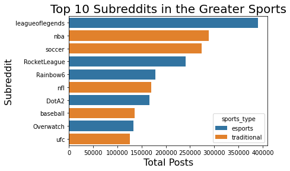

```python
# graphing that data
subs_plot_data = sub_posts.iloc[:10]
sns.barplot(y = subs_plot_data.subreddit, x = subs_plot_data.posts, hue = subs_plot_data.sports_type, dodge =  False, orient = 'h')
plt.xlabel('Total Posts', fontsize = 16)
plt.ylabel('Subreddit', fontsize = 16)
plt.title('Top 10 Subreddits in the Greater Sports', fontsize = 20)
plt.savefig("./data/plots/top_ten_plots.png")
```

```python
# Creating dataframe for the mean length of submission text
sport_text_length = subs.groupby('sports_type').agg(F.avg('sub_text_length').alias('mean_sub_text_length')).toPandas()
sport_text_length.to_csv('./data/csv/sports_post_length.csv')
```

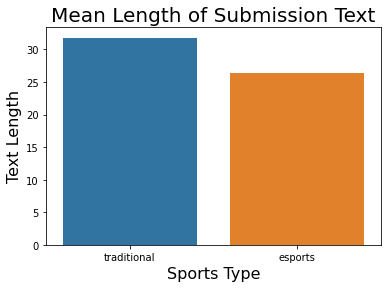

```python
# plotting mean length of submission text by type of sport subreddit
sns.barplot(data = sport_text_length, x = 'sports_type', y = 'mean_sub_text_length', order = ['traditional', 'esports'])
plt.title('Mean Length of Submission Text', fontsize = 20)
plt.ylabel('Text Length', fontsize = 16)
plt.xlabel('Sports Type', fontsize = 16)
plt.savefig("./data/plots/mean_length_submission_text.png")
```

```python
# getting mean comment text length
sport_comm_length = joined_comms.groupby('sports_type').agg(F.avg('comm_text_length').alias('mean_comms_text_length')).toPandas()
sport_comm_length.head()
```

|  | sports_type | mean_comms_text_length |
| --- | --- | --- |
| 0 | traditional | 19.844888 |
| 1 | esports | 27.315952 |

```python
sport_comm_length.to_csv('./data/csv/sport_comm_length.csv') # saving that data
```

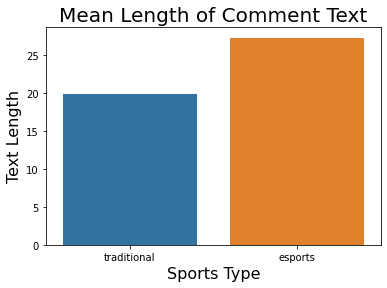

```python
# plotting mean text length by type of community
sns.barplot(data = sport_comm_length, x = 'sports_type', y = 'mean_comms_text_length', order = ['traditional', 'esports'])
plt.title('Mean Length of Comment Text', fontsize = 20)
plt.ylabel('Text Length', fontsize = 16)
plt.xlabel('Sports Type', fontsize = 16)
plt.savefig("./data/plots/mean_length_comment_text.png")
```

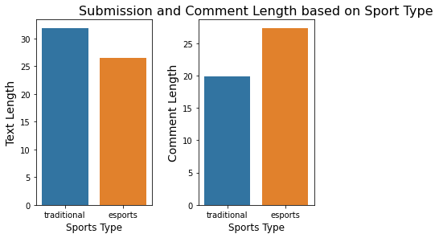

```python
# plotting the mean submission and comment lengths next to each other for comparison
fig, axs = plt.subplots(ncols=2)
sns.barplot(data = sport_text_length, x = 'sports_type', y = 'mean_sub_text_length', order = ['traditional', 'esports'], ax = axs[0])
sns.barplot(data = sport_comm_length, x = 'sports_type', y = 'mean_comms_text_length', order = ['traditional', 'esports'], ax = axs[1])
plt.title('Submission and Comment Length based on Sport Type', loc = 'center', fontsize = 16)
plt.subplots_adjust(left=0.1,
                    bottom=0.1,
                    right=0.9,
                    top=0.9,
                    wspace=0.4,
                    hspace=0.4)
axs[0].set_ylabel('Text Length', fontsize = 14)
axs[0].set_xlabel('Sports Type', fontsize = 12)
axs[1].set_xlabel('Sports Type', fontsize = 12)
axs[1].set_ylabel('Comment Length', fontsize = 14)
plt.savefig("./data/plots/subs_and_comms_length_by_sport_type.png")
```

## More EDA

```python
subs.printSchema()
```

```
root
 |-- author: string (nullable = true)
 |-- submission_id: string (nullable = true)
 |-- date: date (nullable = true)
 |-- edited: string (nullable = true)
 |-- num_comments: long (nullable = true)
 |-- score: long (nullable = true)
 |-- selftext: string (nullable = true)
 |-- spoiler: boolean (nullable = true)
 |-- subreddit: string (nullable = true)
 |-- subreddit_id: string (nullable = true)
 |-- thumbnail: string (nullable = true)
 |-- sports_type: string (nullable = false)
 |-- sub_text_length: integer (nullable = false)
```

Our team was also interested in examining the cyclicality of Reddit activity. One easy way was to see how activity changes by the day of the week. This should be an easy way to point out short-term trends that jump out.

```python
# Creating a 'day of week' variable to establish the day of the week the post was made
days_group = (subs.withColumn('dayOfWeek', F.dayofweek('date'))
              .groupBy('dayOfWeek', 'subreddit')
              .agg({'author' : 'count',
                    'num_comments' : 'mean'})
             .select('dayOfWeek','subreddit',
                     F.col('avg(num_comments)').alias('Mean Comments'),
                     F.col('count(author)').alias('Total Posts'))
             ).toPandas()

# converting the day (e.g. 1) to the written-out version (e.g. Sunday)

def convert_day(day):
    if day == 1:
        return 'Sunday'
    elif day == 2:
        return 'Monday'
    elif day == 3:
        return 'Tuesday'
    elif day == 4:
        return 'Wednesday'
    elif day == 5:
        return 'Thursday'
    elif day == 6:
        return 'Friday'
    elif day == 7:
        return 'Saturday'

# mapping that function to the days_grouping dataset
days_group['dayOfWeek'] = days_group['dayOfWeek'].map(convert_day).astype('category')
days_group.head()
```

|  | dayOfWeek | subreddit | Mean Comments | Total Posts |
| --- | --- | --- | --- | --- |
| 0 | Saturday | tennis | 36.116667 | 8820 |
| 1 | Saturday | RocketLeague | 7.918907 | 35897 |
| 2 | Thursday | leagueoflegends | 16.763627 | 58137 |
| 3 | Thursday | Overwatch | 12.999850 | 19981 |
| 4 | Wednesday | hockey | 82.815404 | 14139 |

```python
days_group.to_csv('./data/csv/days_group.csv') # saving that data
```

```python
# subs.take(5)
```

```python
# filtering submissions by each type of community
sports_subs = subs.filter(subs.sports_type == 'traditional')
esports_subs = subs.filter(subs.sports_type == 'esports')

# Running the day of week aggregation for sports communities
sports_days_info = (sports_subs.withColumn('dayOfWeek', F.dayofweek('date'))
              .groupBy('dayOfWeek')
              .agg({'author' : 'count',
                    'num_comments' : 'mean'})
             .select(F.col('dayOfWeek').alias('Day'),
                     F.col('avg(num_comments)').alias('Mean Comments'),
                     F.col('count(author)').alias('Total Posts'))
             ).toPandas()

sports_days_info['Day'] = sports_days_info['Day'].map(convert_day).astype('category')
sports_days_info.head()
```

|  | Day | Mean Comments | Total Posts |
| --- | --- | --- | --- |
| 0 | Sunday | 65.524880 | 193747 |
| 1 | Friday | 59.252155 | 165914 |
| 2 | Tuesday | 60.779616 | 176773 |
| 3 | Thursday | 59.496070 | 174701 |
| 4 | Wednesday | 59.612397 | 176908 |

```python
# Running the day of week aggregation for esports communities
esports_days_info = (esports_subs.withColumn('dayOfWeek', F.dayofweek('date'))
              .groupBy('dayOfWeek')
              .agg({'author' : 'count',
                    'num_comments' : 'mean'})
             .select(F.col('dayOfWeek').alias('Day'),
                     F.col('avg(num_comments)').alias('Mean Comments'),
                     F.col('count(author)').alias('Total Posts'))
             ).toPandas()

esports_days_info['Day'] = esports_days_info['Day'].map(convert_day).astype('category')
esports_days_info.head()
```

|  | Day | Mean Comments | Total Posts |
| --- | --- | --- | --- |
| 0 | Sunday | 14.234837 | 185018 |
| 1 | Friday | 13.826975 | 190747 |
| 2 | Tuesday | 14.367510 | 187682 |
| 3 | Thursday | 13.433266 | 194241 |
| 4 | Wednesday | 13.252098 | 195583 |

```python
sports_days_info.to_csv('./data/csv/sports_days_info.csv') # saving
esports_days_info.to_csv('./data/csv/esports_days_info.csv') # saving
```

Unsurprisingly, we continue to find that League of Legends is the most dominant esport on Reddit. It has by far the mosts posts for any given day. The actual post activity for each of the esports doesn't seem to rely on day much. This is not the case for traditional sports. The day definitely plays a role in how many posts were made. For example, the most NFL posts were made on Monday, probably in the aftermath of NFL Sunday. Similarly, the UFC subreddit seems the most posts on Sundays, probably in reaction to fights.

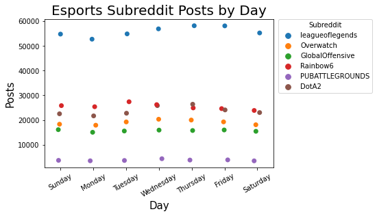

```python
# filtered by type of community for graphing purposes
sports_days = days_group.loc[days_group['subreddit'].isin(['tennis','hockey','nfl','mlb','ufc','nhl','baseball','soccer','nba','Basketball',
                                                          'PremierLeague','mma'])]
esports_days = days_group.loc[days_group['subreddit'].isin(['DotA2','leagueoflegends','GlobalOffensive','PUBATTLEGROUNDS','Rocket League','Rainbow6','Overwatch',
                                                           'Chess'])]

# plotting esports subreddit posts by day
sns.stripplot(data = esports_days, x = 'dayOfWeek', y = 'Total Posts', hue = 'subreddit', size = 7,
              order = ['Sunday','Monday','Tuesday','Wednesday','Thursday','Friday','Saturday'])
plt.ticklabel_format(style='plain', axis='y')
plt.xlabel("Day", fontsize = 15)
plt.ylabel("Posts", fontsize = 15)
plt.xticks(rotation=30)
plt.title('Esports Subreddit Posts by Day', fontsize = 20)
plt.legend(title = 'Subreddit', bbox_to_anchor=(1.02, 1), loc='upper left', borderaxespad=0)
plt.savefig("./data/plots/esports_posts_by_day.png")
```

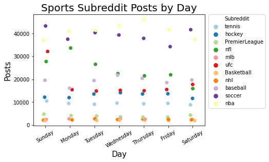

```python
# plotting sports posts by day
sns.stripplot(data = sports_days, x = 'dayOfWeek', y = 'Total Posts', hue = 'subreddit', size = 7, palette = 'Paired',
              order = ['Sunday','Monday','Tuesday','Wednesday','Thursday','Friday','Saturday']) # ideas on strip plot alternatives?
plt.ticklabel_format(style='plain', axis='y')
plt.xlabel("Day", fontsize = 15)
plt.ylabel("Posts", fontsize = 15)
plt.xticks(rotation=30)
plt.title('Sports Subreddit Posts by Day', fontsize = 20)
plt.legend(title = 'Subreddit', bbox_to_anchor=(1.02, 1), loc='upper left', borderaxespad=0)
plt.savefig("./data/plots/sports_posts_by_day.png")
```

In terms of comments, League is the most popular, though it has a noticeable midweek dive. This is somewhat similar for the other esports that each have days of high and low activity. For sports comments, NFL Sunday reigns supreme! After a long day of watching football, it does appear that many Redditors post comments on the NFL subreddit, more than for any sport on any other day! Outside of the NFL though, day does not seem to change comment activity much for each sport.

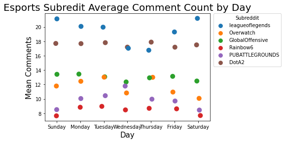

```python
# getting average comment count by day for esports
sns.stripplot(data = esports_days, x = 'dayOfWeek', y = 'Mean Comments', hue = 'subreddit', size = 10,
              order = ['Sunday','Monday','Tuesday','Wednesday','Thursday','Friday','Saturday'])
plt.ticklabel_format(style='plain', axis='y')
plt.xlabel("Day", fontsize = 15)
plt.ylabel("Mean Comments", fontsize = 15)
plt.title('Esports Subredit Average Comment Count by Day', fontsize = 20)
plt.legend(title = 'Subreddit', bbox_to_anchor=(1.02, 1), loc='upper left', borderaxespad=0)
plt.savefig("./data/plots/esports_comments_by_day.png")
```

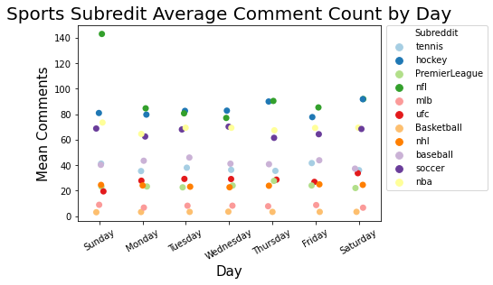

```python
# getting average comment count by day for sports
sns.stripplot(data = sports_days, x = 'dayOfWeek', y = 'Mean Comments', hue = 'subreddit', size = 7, palette = 'Paired',
              order = ['Sunday','Monday','Tuesday','Wednesday','Thursday','Friday','Saturday'])
plt.ticklabel_format(style='plain', axis='y')
plt.xticks(rotation=30)
plt.xlabel("Day", fontsize = 15)
plt.ylabel("Mean Comments", fontsize = 15)
plt.title('Sports Subredit Average Comment Count by Day', fontsize = 20)
plt.legend(title = 'Subreddit', bbox_to_anchor=(1.02, 1), loc='upper left', borderaxespad=0)
plt.savefig("./data/plots/sports_comment_count_by_day.png")
```

```python
# getting the total number of comments by day for both communities
comments_by_day = joined_comms.groupBy('days_since_post').agg({'author' : 'count'}).toPandas()
comments_by_day.days_since_post = comments_by_day.days_since_post.dt.days
comments_by_day.head()
```

|  | days_since_post | count(author) |
| --- | --- | --- |
| 0 | 100 | 751 |
| 1 | 62 | 1141 |
| 2 | 78 | 1031 |
| 3 | 326 | 11 |
| 4 | 92 | 835 |

```python
comments_by_day.to_csv('./data/csv/comments_by_day.csv') # saving
```

Next is to see how many comments are posted on each day out from the original post. Here, we actually have to take the logarithm of the total number of comments for each day. This is because, the highest comment count frequencies come right as the post comes out. Within the first few days, the total comments plumments by orders of magnitude. To reflect this while scaling the data, a log transformation was used.

Using the below plot, you can see that the first 10 or so days of a post sees significantly more comment traffic than anything after. Most posts also start seeing noticeably less comments after ~175 days. After that, there is some fluctuation, with the longest lived posts seeming to tail off at around 1.5 years.

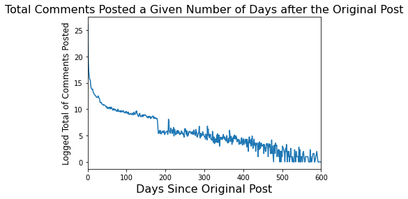

```python
# plotting comments by the time since the original post
import numpy as np

fig, ax = plt.subplots()
sns.lineplot(x = (comments_by_day.days_since_post), y = np.log2(comments_by_day['count(author)']))
plt.ticklabel_format(style='plain', axis='y')
plt.xlabel("Days Since Original Post", fontsize = 16)
plt.ylabel("Logged Total of Comments Posted", fontsize = 12)
plt.title("Total Comments Posted a Given Number of Days after the Original Post", fontsize = 16)
ax.set_xlim(0, 600)
plt.savefig("./data/plots/total_comments_number_days_after_post.png")
```

Finally, to launch a small foray into sentiment analysis, we will plot the controversiality of posts. Reddit actually calculates this natively as a ratio of Upvotes to Downvotes. The closer to 1, the more 'controversial' a post is. The further away from 1, the less controversial it is. We will collect the average controversiality of various subreddits below:

```python
# looking at reddit's controversy score + summarizing by subreddit and sports_type
controversiality = joined_comms.groupby('subreddit').agg(F.avg('controversiality').alias('mean_controversy_rating')).withColumn('sports_type', when(joined_comms.subreddit.isin(traditional_sports), 'traditional').otherwise('esports')).toPandas()
controversiality.head()
```

|  | subreddit | mean_controversy_rating | sports_type |
| --- | --- | --- | --- |
| 0 | hockey | 0.037132 | traditional |
| 1 | PremierLeague | 0.048957 | traditional |
| 2 | DotA2 | 0.035692 | esports |
| 3 | ufc | 0.043388 | traditional |
| 4 | Basketball | 0.008370 | traditional |

```python
controversiality.to_csv('./data/csv/controversiality.csv') # saving
```

Using the chart below, we can see taht soccer and Premier League subreddits are, on average, the most controversial. In fact, the 8 of the 9 most controversial subreddits are all traditional sports, with only two esports subreddits cracking the top ten (r/leagueoflegends and r/DotA2). Another interesting finding is that, while r/nba has the third-highest controversy rating, r/basketball has the lowest!

In the future, we can use the controversy scores by comparing them to our own sentiment analysis and hate speech analysis during the NLP portion of this project.

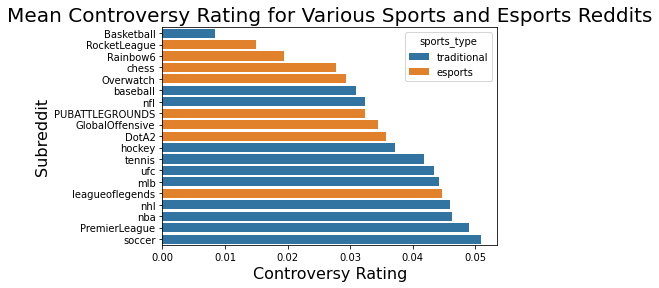

```python
# plotting controversy score by subreddit
sns.barplot(data = controversiality, x = 'mean_controversy_rating', y = 'subreddit', hue = 'sports_type', orient = 'h', order = controversiality.sort_values("mean_controversy_rating").subreddit, dodge = False)
plt.title('Mean Controversy Rating for Various Sports and Esports Reddits', fontsize = 20)
plt.ylabel('Subreddit', fontsize = 16)
plt.xlabel('Controversy Rating', fontsize = 16)
plt.savefig("./data/plots/controversy_by_subreddit.png")
```